# Bayesian Linear Analysis

Megan Feddern

2023-04-28

Mapping Bakun Index locations

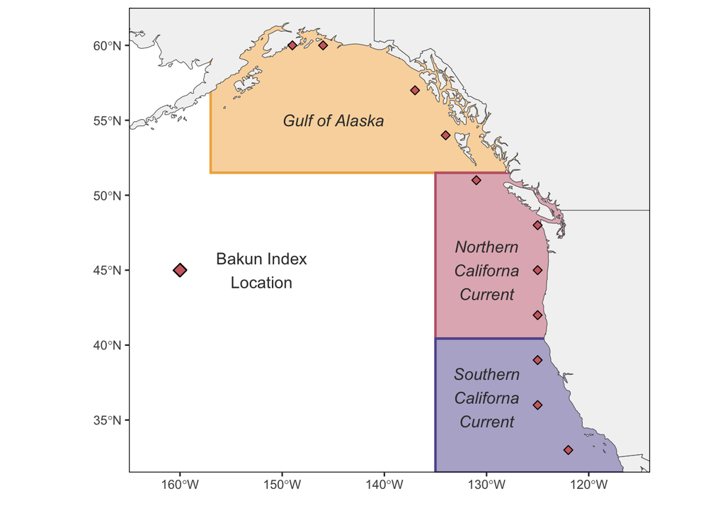

```r
map
```

## Combining Bakun Data

Run the STAN model outside of markdown file using “STANrun.R” which exports the posteriors so that the model does not run in markdown when you knit.

## STAN Model

Bayesian linear model with era specific intercept and slope and region specific slope,

$$Upwelling = \alpha_{e,r} +
\beta_{e,r}*PDO +\sigma$$
where *e* is factor “era” corresponding to eras 1967 - 1988, 1989 - 2013, and 2014 - 2022 and *r* corresponds to regions Southern California Current (south of Mendocino), Northern California Current (Mendocino to Vancouver Island), and Gulf of Alaska (north of Vancover Island).

| Parameter | Description | Prior |
| --- | --- | --- |
| $\alpha_{e,r}$ | Era and region specific anomaly | $~ Normal(0,10)$ |
| $\beta_{e,r}$ | Upwelling-PDO relationship by era and region | $~ Normal(0,10)$ |
| $\sigma$ | Combined observation and process error | $~ Normal(0,10)[0,]$ |

## Monthly Mean Model

Linear relationship between monthly PDO Index and monthly upwelling (Bakun 1˚ 6-hourly) for each era and each region estimated from a Bayesian regression model.

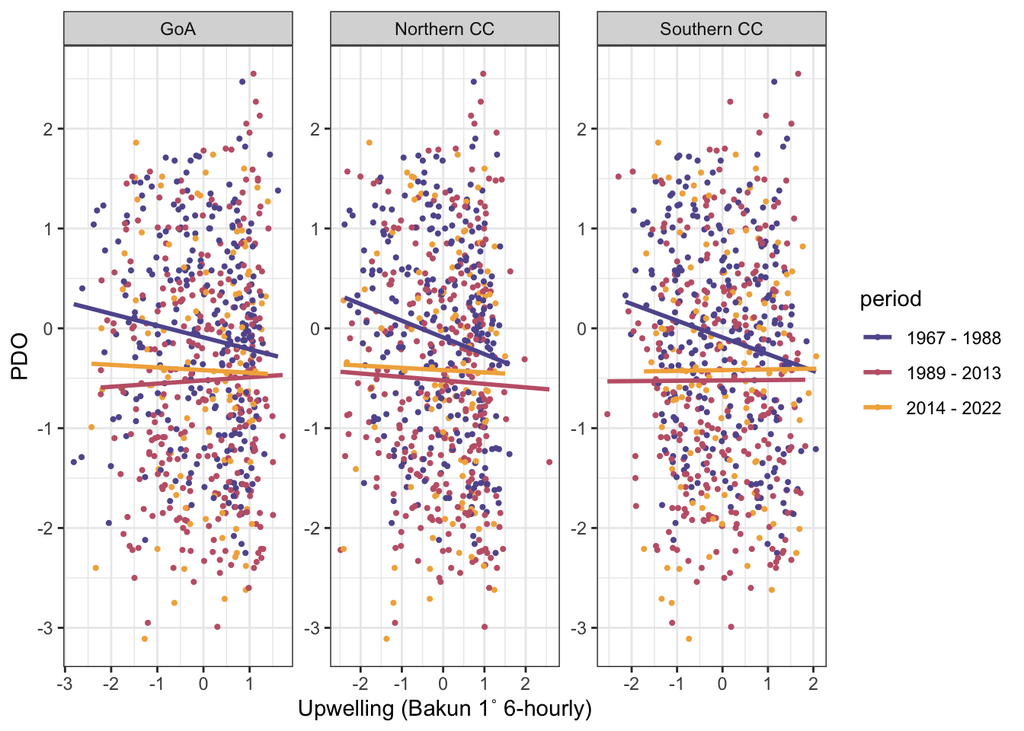

Era specific intercepts across the entire region (Southern California Current to Gulf of Alaska) estimated from a Bayesian regression model

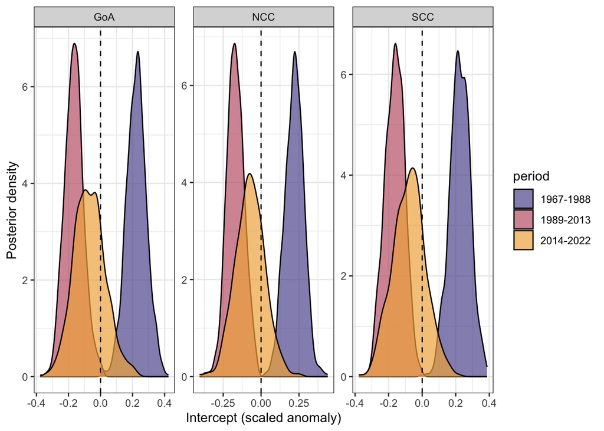

## Winter Model (Nov - March)

Using monthly mean data through winter months (Nov - Mar) where data is standardized for the time period and season

Linear relationship between monthly PDO Index and monthly upwelling (Bakun 1˚ 6-hourly) for each era and each region estimated from a Bayesian regression model using Winter Monthly Means (Nov-March).

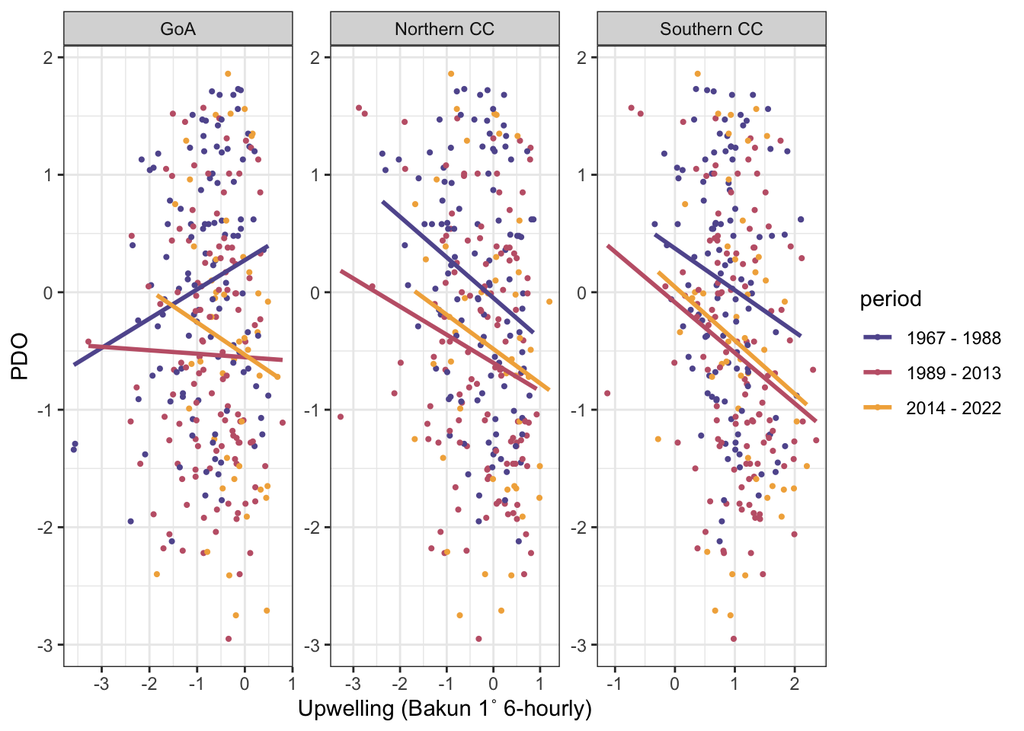

Era specific intercepts across the entire region (Southern California Current to Gulf of Alaska) estimated from a Bayesian regression model for winter months (Nov - March)

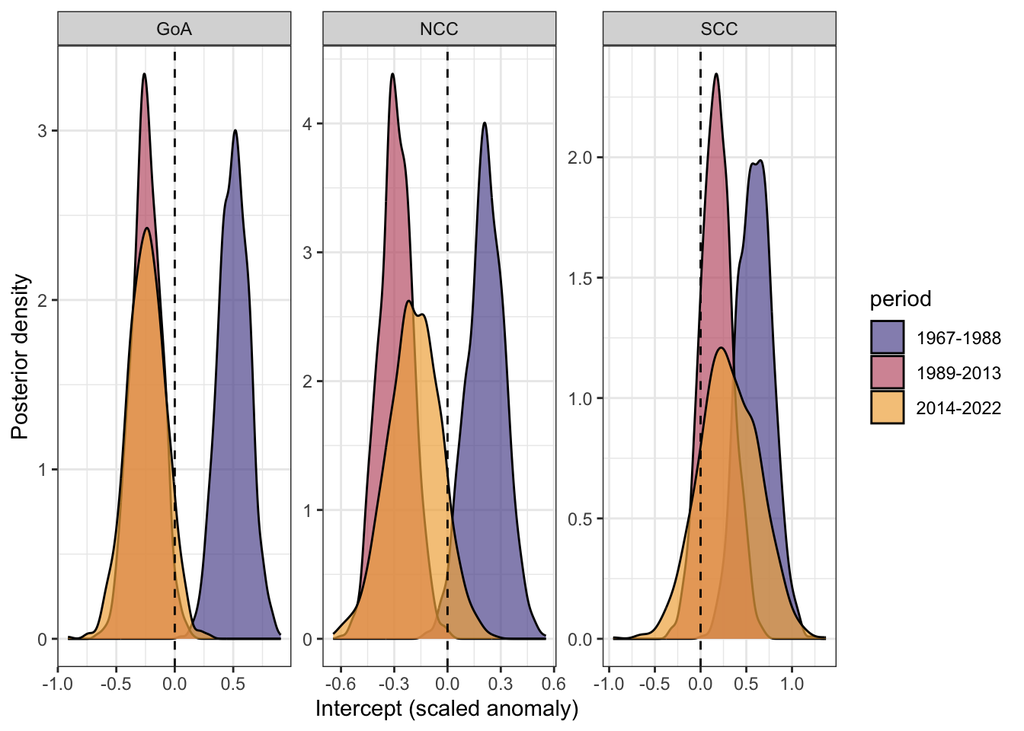

## Spring Model (April - June)

Linear relationship between monthly PDO Index and monthly upwelling (Bakun 1˚ 6-hourly) for each era and each region estimated from a Bayesian regression model using spring Monthly Means (April - June).

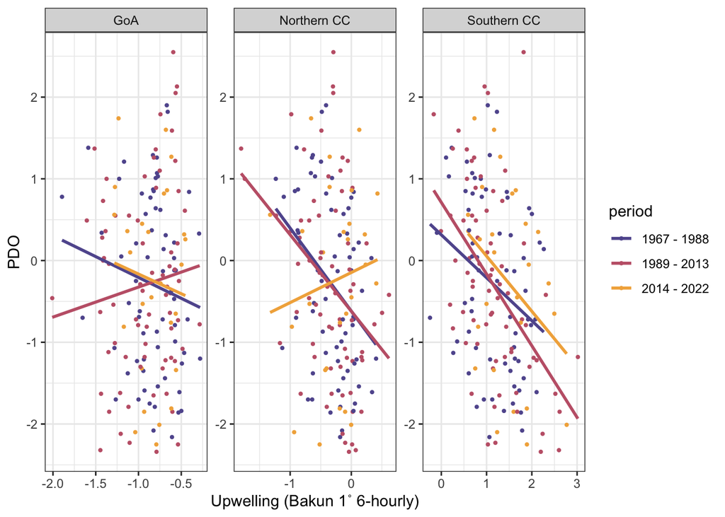

Era specific intercepts across the entire region (Southern California Current to Gulf of Alaska) estimated from a Bayesian regression model for spring monthly means (April - June)

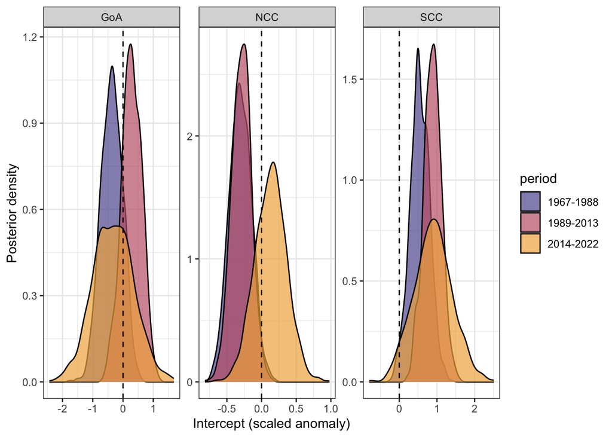

## Summer Model (July - August)

Linear relationship between monthly PDO Index and monthly upwelling (Bakun 1˚ 6-hourly) for each era and each region estimated from a Bayesian regression model using Summer Monthly Means (July - August).

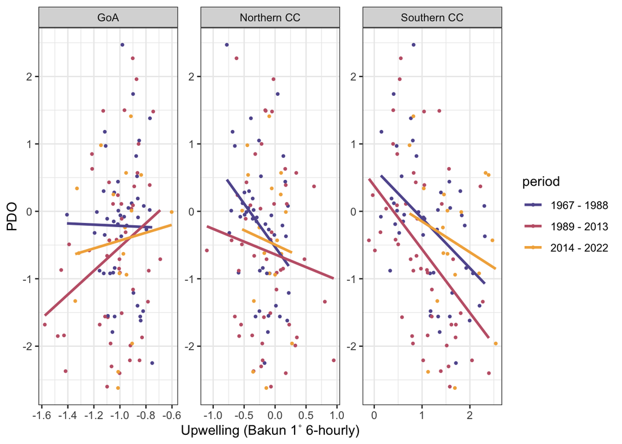

Era specific intercepts across the entire region (Southern California Current to Gulf of Alaska) estimated from a Bayesian regression model for summer months (July - August)

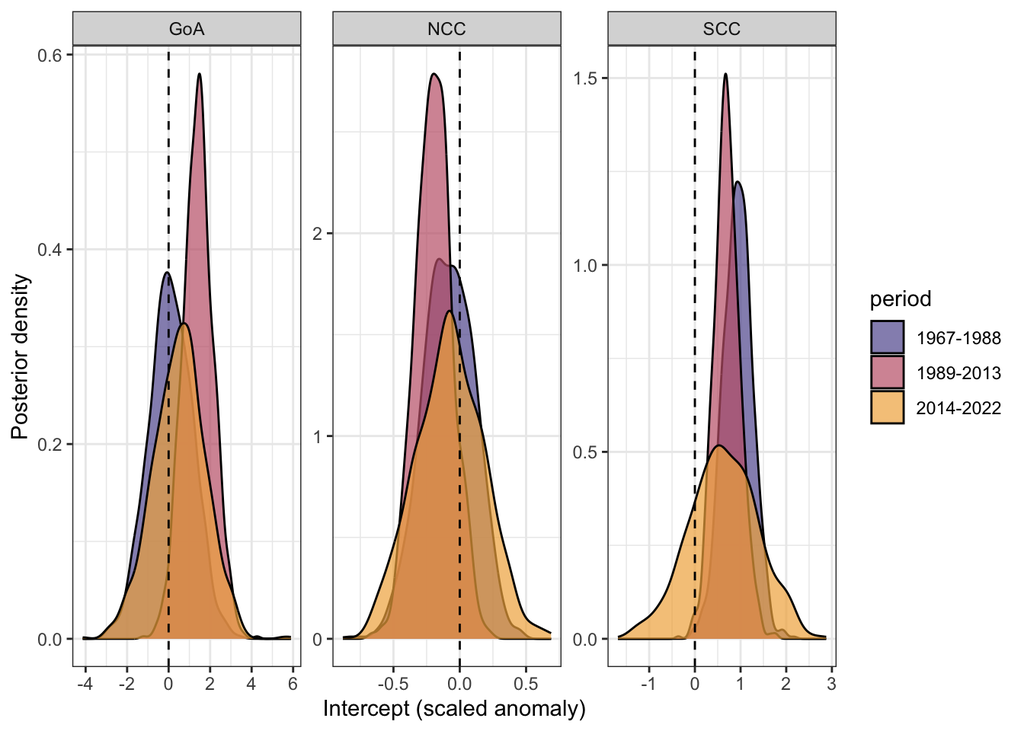

## Questions / Thoughts

1. Currently using monthly mean, could look at seasonal - winter and summer? Which seasons would be the most interesting? It would be easy enough to look at a bunch of relationships, and then have a supplement. Maybe structured in Shiny so you could click through seasons/timeframes and variables. Would take some data organization on the back end but wouldn’t be hard - maybe could even build on the interface as we add taxa to the next phase.
2. I think that this paper would be more compelling if it had some degree of biology. Maybe we could bring in some of the Zoop CalCofi data as a case study within the larger regional analysis and link these changing relationships to an ecosystem response - it would also be a nice thing to build our way up the food web with the salmon/groundfish part of the project and still take a foodweb wide view that was initially in the proposal. Are there are plankton datasets in the Southern California Current and/or GoA we could use?